# acumen benchmark report

Generated 2026-10-27 13:03 UTC · 75 runs · figures show the valid split · arms: noskill, v1 · tasks: filter, n_sig, r_engine, top_gene, unpaired

## Overview

Per-run means over the valid split; error bars are standard errors.

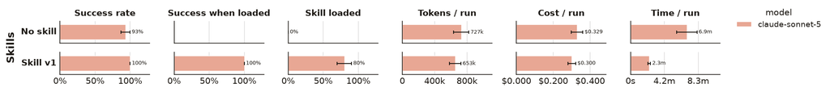

### Success across versions

Each line follows one model's success rate as the skill goes from no skill through each version. Solid lines are the valid tasks and dashed lines are the train tasks. The grey line is the mean across models and sits on top. The newest version has only valid runs, so the train lines stop one step short.

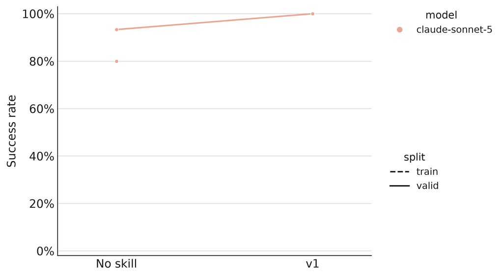

### Cost vs. success

One mark per model and skill version, where colour is the model and the ✕ is that model's no-skill baseline. Arrows join one model's own marks in version order, baseline to v1 to v2 and on, so a chain is that model's path and never crosses to another. The grey mark pools every model for that version, with standard errors on both axes, and its chain is the pooled path. The staircase is the Pareto frontier: anything below and to the right of it is dominated, because something on the line costs less *and* succeeds more.

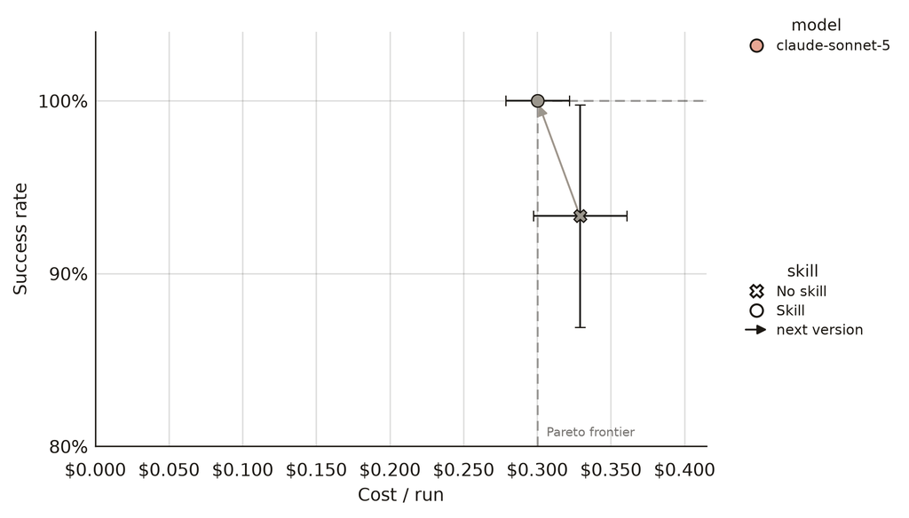

### Is the difference real?

Each version is compared with the baseline on two separate questions: does it succeed more often, and does it cost less per run? Each is a one-sided test, and each is corrected on its own, with a Benjamini–Hochberg false-discovery rate (*FDR q*) across the versions. Success is one family and cost is another, so a version can show a real gain on success, on cost, or on both, and the table says which. A gain the resampling cannot tell apart from noise leaves q high, which says the evidence is thin rather than that the version is bad. Best value in each column is **bold**, highest for the rates and lowest for cost and for the p- and q-values. *On frontier* is how often an arm holds the Pareto frontier across resamples. Resampling is over the 5 tasks, paired across arms, so the unit is the task rather than the run.

| Skill | Success rate | Cost / run | On frontier | Success vs No skill Δ rate | Success vs No skill p | Success vs No skill FDR q | Cost vs No skill Δ cost | Cost vs No skill p | Cost vs No skill FDR q |
| --- | --- | --- | --- | --- | --- | --- | --- | --- | --- |
| No skill | 93.3% | $0.329 | 13.0% | — | — | — | — | — | — |
| Skill v1 | **100.0%** | **$0.300** | **93.4%** | +6.7pp | 0.323 | 0.323 | -$0.029 | 0.130 | 0.130 |

### Did it help when it actually loaded?

If a skill never loads, the agent never reads it, so that run tells us nothing about the skill itself and only measures the baseline. Setting those runs aside lets us see whether the guidance helped in the runs where it did reach the agent. This helps tell apart a skill that fails to load from one that loads but still doesn't help. In the plot below, every dot is one model on one skill version. The colour shows the change in success rate against the baseline, green for better and red for worse. The size shows how often the skill loaded, and a hollow ring means it never did. Each loaded run is compared with the baseline on the very same task and model, and those differences are averaged, so the number is a real effect and does not depend on which tasks happened to load. It is still measured only on the tasks that loaded, and it does not test whether a gain is more than noise. For that, look at the significance test above.

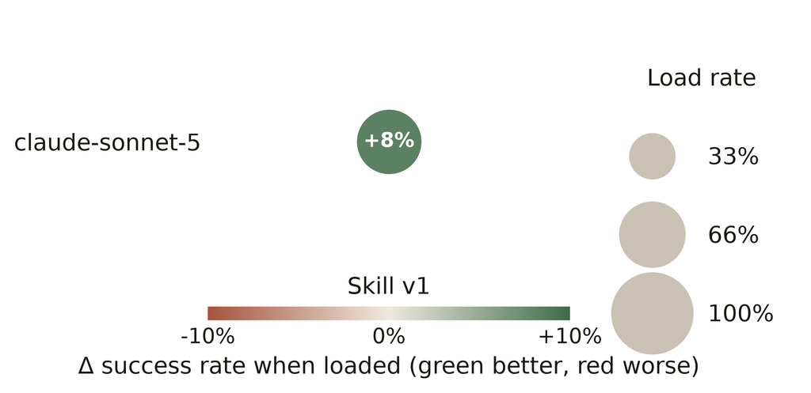

## Held-out test

This is the truly held-out split. It is benched once at the very end of a fit, on the best kept version and the baseline, and nothing in the loop ever sees it. Training learns from the train split and the best version is picked on valid, so the test split is the first and only place the skill meets these tasks. Read it as the honest final estimate of what the skill buys.

Skill version used for the held-out test: **v1**, the best on validation and the version to ship (`acumen ship --skill v1`).

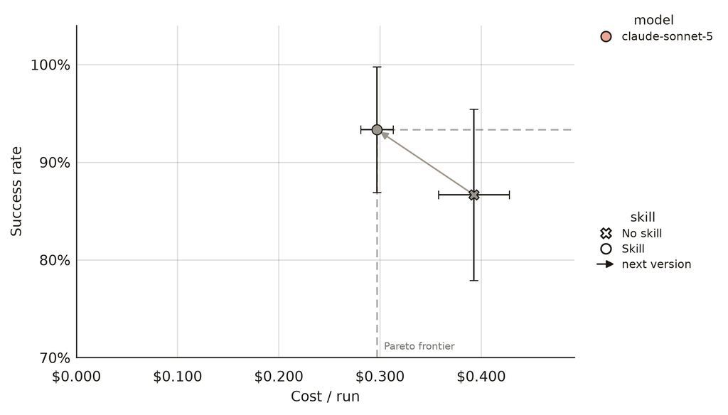

| Skill | Success rate | Cost / run | On frontier | Success vs No skill Δ rate | Success vs No skill p | Success vs No skill FDR q | Cost vs No skill Δ cost | Cost vs No skill p | Cost vs No skill FDR q |
| --- | --- | --- | --- | --- | --- | --- | --- | --- | --- |
| No skill | 86.7% | $0.393 | 20.1% | — | — | — | — | — | — |
| Skill v1 | **93.3%** | **$0.297** | **98.6%** | +6.7pp | 0.374 | 0.374 | -$0.096 | 0.017 | 0.017 |

## Per-task breakdown

### filter

**train:** `kang2018_pb.h5ad` in the working directory holds Kang et al. 2018 PBMCs: raw UMI counts in `X`; `obs` columns `sample` (one id per patient x condition), `replicate` (patient), `label` (`ctrl` or `stim`, interferon-beta) and `cell_type`. Pseudobulk the B cells: sum raw counts per `sample` over that cell type's cells; drop samples with fewer than 30 cells; keep genes detected (count > 0) in at least 0.1 of the cells of the kept samples. Report only `<samples kept>/<genes kept>`, for example `12/3456`.

**valid:** `kang2018_pb.h5ad` in the working directory holds Kang et al. 2018 PBMCs: raw UMI counts in `X`; `obs` columns `sample` (one id per patient x condition), `replicate` (patient), `label` (`ctrl` or `stim`, interferon-beta) and `cell_type`. Pseudobulk the NK cells: sum raw counts per `sample` over that cell type's cells; drop samples with fewer than 30 cells; keep genes detected (count > 0) in at least 0.05 of the cells of the kept samples. Report only `<samples kept>/<genes kept>`, for example `12/3456`.

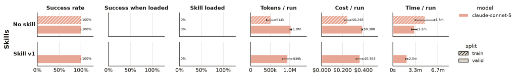

### n_sig

**train:** `kang2018_pb.h5ad` in the working directory holds Kang et al. 2018 PBMCs: raw UMI counts in `X`; `obs` columns `sample` (one id per patient x condition), `replicate` (patient), `label` (`ctrl` or `stim`, interferon-beta) and `cell_type`. Pseudobulk the CD14+ Monocytes: sum raw counts per `sample` over that cell type's cells; drop samples with fewer than 20 cells; keep genes detected (count > 0) in at least 0.1 of the cells of the kept samples. Then test stim vs ctrl: design `~ replicate + label`, no fold-change shrinkage, independent-filtering alpha 0.05. Fit with PyDESeq2. A gene is significant when padj < 0.05 and |log2 fold change| > 1; a missing padj is not significant. Save the results table and figures in the working directory. Report only the number of significant genes.

**valid:** `kang2018_pb.h5ad` in the working directory holds Kang et al. 2018 PBMCs: raw UMI counts in `X`; `obs` columns `sample` (one id per patient x condition), `replicate` (patient), `label` (`ctrl` or `stim`, interferon-beta) and `cell_type`. Pseudobulk the FCGR3A+ Monocytes: sum raw counts per `sample` over that cell type's cells; drop samples with fewer than 20 cells; keep genes detected (count > 0) in at least 0.05 of the cells of the kept samples. Then test stim vs ctrl: design `~ replicate + label`, no fold-change shrinkage, independent-filtering alpha 0.1. Fit with PyDESeq2. A gene is significant when padj < 0.1 and |log2 fold change| > 0.5; a missing padj is not significant. Save the results table and figures in the working directory. Report only the number of significant genes.

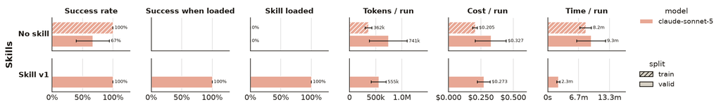

### r_engine

**train:** `kang2018_pb.h5ad` in the working directory holds Kang et al. 2018 PBMCs: raw UMI counts in `X`; `obs` columns `sample` (one id per patient x condition), `replicate` (patient), `label` (`ctrl` or `stim`, interferon-beta) and `cell_type`. Pseudobulk the CD14+ Monocytes: sum raw counts per `sample` over that cell type's cells; drop samples with fewer than 20 cells; keep genes detected (count > 0) in at least 0.2 of the cells of the kept samples. Then test stim vs ctrl: design `~ replicate + label`, no fold-change shrinkage, independent-filtering alpha 0.05. Fit with DESeq2 in R (`Rscript` is on PATH). A gene is significant when padj < 0.05 and |log2 fold change| > 1; a missing padj is not significant. Save the results table and figures in the working directory. Report only the number of significant genes.

**valid:** `kang2018_pb.h5ad` in the working directory holds Kang et al. 2018 PBMCs: raw UMI counts in `X`; `obs` columns `sample` (one id per patient x condition), `replicate` (patient), `label` (`ctrl` or `stim`, interferon-beta) and `cell_type`. Pseudobulk the B cells: sum raw counts per `sample` over that cell type's cells; drop samples with fewer than 20 cells; keep genes detected (count > 0) in at least 0.1 of the cells of the kept samples. Then test stim vs ctrl: design `~ replicate + label`, no fold-change shrinkage, independent-filtering alpha 0.05. Fit with DESeq2 in R (`Rscript` is on PATH). A gene is significant when padj < 0.05 and |log2 fold change| > 1; a missing padj is not significant. Save the results table and figures in the working directory. Report only the number of significant genes.

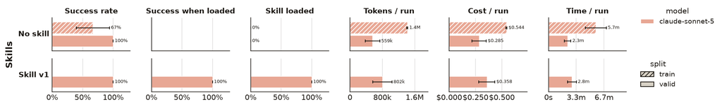

### top_gene

**train:** `kang2018_pb.h5ad` in the working directory holds Kang et al. 2018 PBMCs: raw UMI counts in `X`; `obs` columns `sample` (one id per patient x condition), `replicate` (patient), `label` (`ctrl` or `stim`, interferon-beta) and `cell_type`. Pseudobulk the CD4 T cells: sum raw counts per `sample` over that cell type's cells; drop samples with fewer than 20 cells; keep genes detected (count > 0) in at least 0.1 of the cells of the kept samples. Then test stim vs ctrl: design `~ replicate + label`, no fold-change shrinkage, independent-filtering alpha 0.05. Fit with PyDESeq2. A gene is significant when padj < 0.05 and |log2 fold change| > 1; a missing padj is not significant. Save the results table and figures in the working directory. Report only the significant gene with the most negative log2 fold change.

**valid:** `kang2018_pb.h5ad` in the working directory holds Kang et al. 2018 PBMCs: raw UMI counts in `X`; `obs` columns `sample` (one id per patient x condition), `replicate` (patient), `label` (`ctrl` or `stim`, interferon-beta) and `cell_type`. Pseudobulk the B cells: sum raw counts per `sample` over that cell type's cells; drop samples with fewer than 20 cells; keep genes detected (count > 0) in at least 0.1 of the cells of the kept samples. Then test stim vs ctrl: design `~ replicate + label`, no fold-change shrinkage, independent-filtering alpha 0.05. Fit with PyDESeq2. A gene is significant when padj < 0.05 and |log2 fold change| > 1; a missing padj is not significant. Save the results table and figures in the working directory. Report only the significant gene with the most negative log2 fold change.

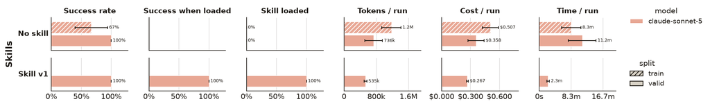

### unpaired

**train:** `kang2018_pb.h5ad` in the working directory holds Kang et al. 2018 PBMCs: raw UMI counts in `X`; `obs` columns `sample` (one id per patient x condition), `replicate` (patient), `label` (`ctrl` or `stim`, interferon-beta) and `cell_type`. Pseudobulk the NK cells: sum raw counts per `sample` over that cell type's cells; drop samples with fewer than 20 cells; keep genes detected (count > 0) in at least 0.1 of the cells of the kept samples. Then test stim vs ctrl: design `~ label`, no fold-change shrinkage, independent-filtering alpha 0.05. Fit with PyDESeq2. A gene is significant when padj < 0.05 and |log2 fold change| > 1; a missing padj is not significant. Save the results table and figures in the working directory. Report only the number of significant genes.

**valid:** `kang2018_pb.h5ad` in the working directory holds Kang et al. 2018 PBMCs: raw UMI counts in `X`; `obs` columns `sample` (one id per patient x condition), `replicate` (patient), `label` (`ctrl` or `stim`, interferon-beta) and `cell_type`. Pseudobulk the CD8 T cells: sum raw counts per `sample` over that cell type's cells; drop samples with fewer than 20 cells; keep genes detected (count > 0) in at least 0.1 of the cells of the kept samples. Then test stim vs ctrl: design `~ label`, no fold-change shrinkage, independent-filtering alpha 0.05. Fit with PyDESeq2. A gene is significant when padj < 0.05 and |log2 fold change| > 1; a missing padj is not significant. Save the results table and figures in the working directory. Report only the number of significant genes.

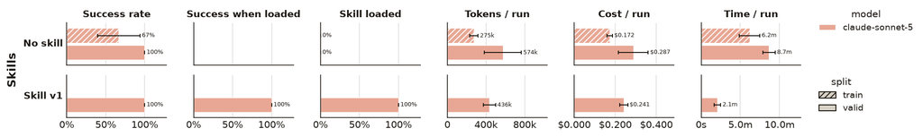

## Skill versions

Why each version was written, and what changed from its parent.

### Skill v1

initial draft

(no rationale recorded)

Initial version — no parent to diff against.

## Runs

Full data: report.csv

| arm | split | task | model | rep | skill loaded | reason | turns | total tok | cost / run $ | time | transcript |
| --- | --- | --- | --- | --- | --- | --- | --- | --- | --- | --- | --- |
| noskill | test | filter | claude-sonnet-5 | 1 | — | ok | 19 | 774,628 | 0.301 | 2.5m | view |
| noskill | test | filter | claude-sonnet-5 | 2 | — | ok | 27 | 1,192,537 | 0.439 | 11.8m | view |
| noskill | test | filter | claude-sonnet-5 | 3 | — | ok | 27 | 1,188,947 | 0.458 | 9.8m | view |
| noskill | test | n_sig | claude-sonnet-5 | 1 | — | ok | 12 | 483,374 | 0.276 | 12.8m | view |
| noskill | test | n_sig | claude-sonnet-5 | 2 | — | ok | 6 | 235,696 | 0.165 | 8.5m | view |
| noskill | test | n_sig | claude-sonnet-5 | 3 | — | ok | 22 | 1,017,575 | 0.427 | 17.4m | view |
| noskill | test | r_engine | claude-sonnet-5 | 1 | — | ok | 26 | 1,200,418 | 0.492 | 6.7m | view |
| noskill | test | r_engine | claude-sonnet-5 | 2 | — | ok | 12 | 500,754 | 0.250 | 3.2m | view |
| noskill | test | r_engine | claude-sonnet-5 | 3 | — | max_turns | 31 | 1,382,430 | 0.530 | 5.1m | view |
| noskill | test | top_gene | claude-sonnet-5 | 1 | — | ok | 26 | 1,248,419 | 0.540 | 14.1m | view |
| noskill | test | top_gene | claude-sonnet-5 | 2 | — | ok | 13 | 545,801 | 0.281 | 8.5m | view |
| noskill | test | top_gene | claude-sonnet-5 | 3 | — | ok | 23 | 1,078,848 | 0.509 | 11.1m | view |
| noskill | test | unpaired | claude-sonnet-5 | 1 | — | ok | 7 | 275,763 | 0.179 | 13.4m | view |
| noskill | test | unpaired | claude-sonnet-5 | 2 | — | max_turns | 31 | 1,415,708 | 0.556 | 8.9m | view |
| noskill | test | unpaired | claude-sonnet-5 | 3 | — | ok | 24 | 1,123,466 | 0.486 | 9.9m | view |
| noskill | train | filter | claude-sonnet-5 | 1 | — | ok | 17 | 697,732 | 0.293 | 3.2m | view |
| noskill | train | filter | claude-sonnet-5 | 2 | — | ok | 13 | 534,043 | 0.269 | 7.5m | view |
| noskill | train | filter | claude-sonnet-5 | 3 | — | ok | 8 | 310,941 | 0.181 | 3.4m | view |
| noskill | train | n_sig | claude-sonnet-5 | 1 | — | ok | 7 | 273,550 | 0.173 | 5.7m | view |
| noskill | train | n_sig | claude-sonnet-5 | 2 | — | ok | 8 | 320,803 | 0.205 | 9.7m | view |
| noskill | train | n_sig | claude-sonnet-5 | 3 | — | ok | 12 | 491,486 | 0.236 | 9.2m | view |
| noskill | train | r_engine | claude-sonnet-5 | 1 | — | max_turns | 31 | 1,432,223 | 0.542 | 8.1m | view |
| noskill | train | r_engine | claude-sonnet-5 | 2 | — | ok | 31 | 1,387,805 | 0.537 | 3.9m | view |
| noskill | train | r_engine | claude-sonnet-5 | 3 | — | ok | 31 | 1,426,167 | 0.554 | 5.1m | view |
| noskill | train | top_gene | claude-sonnet-5 | 1 | — | ok | 28 | 1,340,555 | 0.574 | 11.5m | view |
| noskill | train | top_gene | claude-sonnet-5 | 2 | — | max_turns | 31 | 1,476,718 | 0.607 | 3.3m | view |
| noskill | train | top_gene | claude-sonnet-5 | 3 | — | ok | 16 | 700,041 | 0.341 | 10.2m | view |
| noskill | train | unpaired | claude-sonnet-5 | 1 | — | ok | 6 | 233,677 | 0.162 | 7.6m | view |
| noskill | train | unpaired | claude-sonnet-5 | 2 | — | wrong_answer | 6 | 230,565 | 0.156 | 3.6m | view |
| noskill | train | unpaired | claude-sonnet-5 | 3 | — | ok | 9 | 360,795 | 0.199 | 7.3m | view |
| noskill | valid | filter | claude-sonnet-5 | 1 | — | ok | 23 | 987,463 | 0.383 | 3.6m | view |
| noskill | valid | filter | claude-sonnet-5 | 2 | — | ok | 25 | 1,070,654 | 0.397 | 3.6m | view |
| noskill | valid | filter | claude-sonnet-5 | 3 | — | ok | 24 | 1,022,452 | 0.384 | 2.3m | view |
| noskill | valid | n_sig | claude-sonnet-5 | 1 | — | max_turns | 31 | 1,455,058 | 0.566 | 3.1m | view |
| noskill | valid | n_sig | claude-sonnet-5 | 2 | — | ok | 11 | 450,555 | 0.228 | 12.5m | view |
| noskill | valid | n_sig | claude-sonnet-5 | 3 | — | ok | 8 | 318,482 | 0.186 | 12.4m | view |
| noskill | valid | r_engine | claude-sonnet-5 | 1 | — | ok | 20 | 908,611 | 0.418 | 3.1m | view |
| noskill | valid | r_engine | claude-sonnet-5 | 2 | — | ok | 11 | 449,239 | 0.238 | 2.0m | view |
| noskill | valid | r_engine | claude-sonnet-5 | 3 | — | ok | 8 | 319,319 | 0.199 | 1.8m | view |
| noskill | valid | top_gene | claude-sonnet-5 | 1 | — | ok | 9 | 364,956 | 0.203 | 4.0m | view |
| noskill | valid | top_gene | claude-sonnet-5 | 2 | — | ok | 24 | 1,122,704 | 0.489 | 15.3m | view |
| noskill | valid | top_gene | claude-sonnet-5 | 3 | — | ok | 16 | 718,898 | 0.383 | 14.4m | view |
| noskill | valid | unpaired | claude-sonnet-5 | 1 | — | ok | 21 | 954,535 | 0.432 | 8.0m | view |
| noskill | valid | unpaired | claude-sonnet-5 | 2 | — | ok | 10 | 410,987 | 0.230 | 10.2m | view |
| noskill | valid | unpaired | claude-sonnet-5 | 3 | — | ok | 9 | 357,679 | 0.200 | 7.8m | view |
| v1 | test | filter | claude-sonnet-5 | 1 | no | wrong_answer | 24 | 1,015,508 | 0.380 | 2.3m | view |
| v1 | test | filter | claude-sonnet-5 | 2 | no | ok | 19 | 802,392 | 0.326 | 6.0m | view |
| v1 | test | filter | claude-sonnet-5 | 3 | no | ok | 18 | 751,559 | 0.322 | 5.3m | view |
| v1 | test | n_sig | claude-sonnet-5 | 1 | yes | ok | 14 | 628,288 | 0.333 | 3.5m | view |
| v1 | test | n_sig | claude-sonnet-5 | 2 | yes | ok | 16 | 756,697 | 0.444 | 8.4m | view |
| v1 | test | n_sig | claude-sonnet-5 | 3 | yes | ok | 13 | 549,114 | 0.277 | 2.9m | view |
| v1 | test | r_engine | claude-sonnet-5 | 1 | yes | ok | 13 | 559,696 | 0.277 | 2.8m | view |
| v1 | test | r_engine | claude-sonnet-5 | 2 | yes | ok | 13 | 558,210 | 0.274 | 2.6m | view |
| v1 | test | r_engine | claude-sonnet-5 | 3 | yes | ok | 15 | 662,057 | 0.346 | 3.1m | view |
| v1 | test | top_gene | claude-sonnet-5 | 1 | yes | ok | 15 | 646,203 | 0.280 | 6.4m | view |
| v1 | test | top_gene | claude-sonnet-5 | 2 | yes | ok | 12 | 494,993 | 0.241 | 2.1m | view |
| v1 | test | top_gene | claude-sonnet-5 | 3 | yes | ok | 11 | 451,746 | 0.239 | 3.1m | view |
| v1 | test | unpaired | claude-sonnet-5 | 1 | yes | ok | 9 | 351,548 | 0.206 | 2.9m | view |
| v1 | test | unpaired | claude-sonnet-5 | 2 | yes | ok | 12 | 502,808 | 0.253 | 2.5m | view |
| v1 | test | unpaired | claude-sonnet-5 | 3 | yes | ok | 12 | 511,022 | 0.257 | 2.9m | view |
| v1 | valid | filter | claude-sonnet-5 | 1 | no | ok | 25 | 1,078,327 | 0.407 | 2.4m | view |
| v1 | valid | filter | claude-sonnet-5 | 2 | no | ok | 17 | 702,711 | 0.296 | 1.8m | view |
| v1 | valid | filter | claude-sonnet-5 | 3 | no | ok | 24 | 1,036,517 | 0.387 | 1.9m | view |
| v1 | valid | n_sig | claude-sonnet-5 | 1 | yes | ok | 18 | 826,115 | 0.369 | 2.9m | view |
| v1 | valid | n_sig | claude-sonnet-5 | 2 | yes | ok | 9 | 343,881 | 0.208 | 1.8m | view |
| v1 | valid | n_sig | claude-sonnet-5 | 3 | yes | ok | 12 | 493,852 | 0.241 | 2.2m | view |
| v1 | valid | r_engine | claude-sonnet-5 | 1 | yes | ok | 17 | 779,003 | 0.370 | 3.2m | view |
| v1 | valid | r_engine | claude-sonnet-5 | 2 | yes | ok | 25 | 1,223,869 | 0.483 | 3.4m | view |
| v1 | valid | r_engine | claude-sonnet-5 | 3 | yes | ok | 10 | 402,854 | 0.220 | 1.8m | view |
| v1 | valid | top_gene | claude-sonnet-5 | 1 | yes | ok | 14 | 599,460 | 0.280 | 1.6m | view |
| v1 | valid | top_gene | claude-sonnet-5 | 2 | yes | ok | 12 | 510,114 | 0.272 | 2.7m | view |
| v1 | valid | top_gene | claude-sonnet-5 | 3 | yes | ok | 12 | 494,168 | 0.248 | 2.6m | view |
| v1 | valid | unpaired | claude-sonnet-5 | 1 | yes | ok | 10 | 402,032 | 0.243 | 2.2m | view |
| v1 | valid | unpaired | claude-sonnet-5 | 2 | yes | ok | 13 | 556,199 | 0.274 | 2.7m | view |
| v1 | valid | unpaired | claude-sonnet-5 | 3 | yes | ok | 9 | 348,358 | 0.206 | 1.3m | view |